# Praktikum 2 - Eksplorasi Data Point Pattern

Author

Putri Nisrina Az-Zahra

Eksplorasi Data Titik

# Review Pola Titik

Titik adalah objek dalam dimensi nol dan menggambarkan sifat dari titik menduduki ruang. Pola keseluruhan titik dalam ruang mencerminkan sifat keseluruhan titik tersebut.

Pola titik spasial muncul di banyak domain. Contohnya lokasi individu dengan penyakit tertentu di sebuah kota, spesies di suatu wilayah, sel dalam jaringan dan sebagainya.

Ada tiga pola titik:

1. **Acak**:

   setiap titik mempunyai peluang yang sama untuk menduduki suatu ruang dan tidak dipengaruhi oleh titik yang lain.
2. **Uniform** :

   setiap titik adalah sejauh mungkin dari titik-titik tetangganya.
3. **Cluster** : Banyak titik terkonsentrasi menduduki pada ruang yang sama, dan ruang yang lain sangat sedikit ditempati oleh titik.

Berikut adalah ilustrasinya.

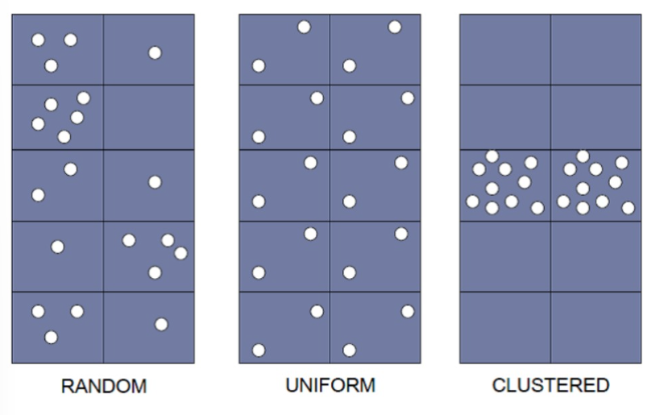

# Contoh Data Titik

Paket spatstat dapat digunakan untuk bekerja dengan pola titik spasial. Paket ini mencakup sejumlah fungsi yang memungkinkan kita melakukan analisis spasial, seperti menilai keacakan pola titik spasial, dan untuk merumuskan dan menyesuaikan model dengan data pola titik.

Berikut adalah contoh data titik yang disertakan dalam paket spatstat, gambaran umum semua data yang ada dalam paket tersebut dapat dilihat [di sini](https://cran.r-project.org/web/packages/spatstat/vignettes/datasets.pdf).

## Dataset Pinus Jepang

```r
library(spatstat)
```

```r
japanesepines
```

```
Planar point pattern: 65 points
window: rectangle = [0, 1] x [0, 1] units (one unit = 5.7 metres)
```

```r
class(japanesepines)
```

```
[1] "ppp"
```

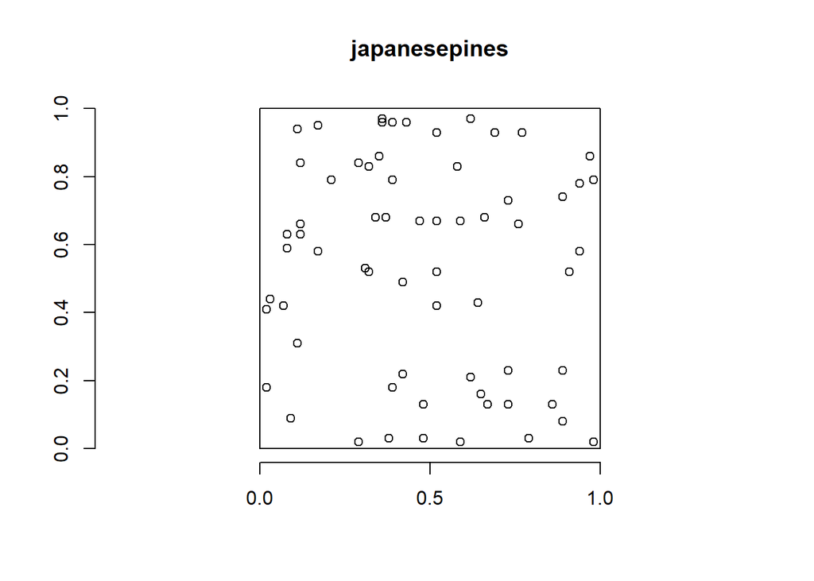

```r
plot(japanesepines)
axis(1)
axis(2)
```

## Dataset Pohon di Hutan

Pola titik spasial juga dapat memiliki nilai terkait, dan ini disebut pola titik bertanda. Contoh pola titik bertanda diberikan oleh data `longleaf` . Data tersebut mencatat lokasi dan diameter dari 584 pohon pinus berdaun panjang (*Pinus palustris*) di wilayah seluas 200 x 200 meter di bagian selatan Georgia (AS). Data tersebut dikumpulkan dan dianalisis oleh Platt, Evans dan Rathbun (1988).

Ini adalah pola titik yang ditandai; tanda yang terkait dengan pohon adalah diameter setinggi dada (dbh), sebuah ukuran yang mudah digunakan untuk mengukur ukuran dan usianya. Beberapa analisis hanya mempertimbangkan pohon-pohon “dewasa” yang secara konvensional didefinisikan sebagai pohon-pohon dengan dbh lebih besar atau sama dengan 30 cm

```r
longleaf
```

```
Marked planar point pattern: 584 points
marks are numeric, of storage type  'double'
window: rectangle = [0, 200] x [0, 200] metres
```

```r
class(longleaf)
```

```
[1] "ppp"
```

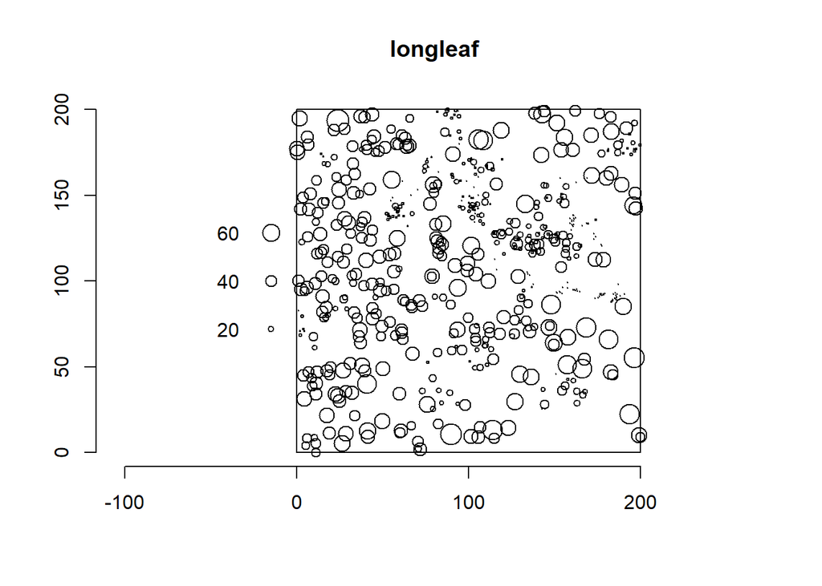

```r
plot(longleaf)
axis(1)
axis(2)
```

## Dataset Kebakaran Hutan Castilla-La Mancha

Data clmfiresberisi lokasi dan informasi kebakaran hutan di wilayah Castilla-La Mancha di Spanyol antara tahun 1998 dan 2007. Wilayah ini berukuran sekitar 400 x 400 kilometer. Koordinat dicatat dalam satuan kilometer.

Ilustrasi berikut menunjukkan lokasi kebakaran dan empat tanda dengan informasi tentang kebakaran, yaitu penyebab kebakaran (`cause`), total area yang terbakar (`burnt.area`) dalam hektar, tanggal kebakaran (`date`), dan jumlah hari yang telah berlalu sejak 1 Januari 1998 (`julian.date`).

```r
clmfires
```

```
Marked planar point pattern: 8488 points
Mark variables: cause, burnt.area, date, julian.date
window: polygonal boundary
enclosing rectangle: [4.1311, 391.3795] x [18.565, 385.189] kilometres
```

```r
class(clmfires)
```

```
[1] "ppp"
```

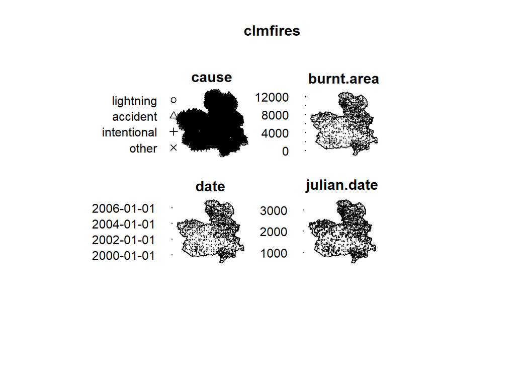

```r
plot(clmfires)
```

## Dataset Tumor Hamster

Data tersebut `hamster`menyediakan pusat-pusat nukleus sel-sel tertentu di bagian jaringan dari limfoma yang diinduksi laboratorium di ginjal hamster. Nukleus diklasifikasikan sebagai “piknotik” (sesuai dengan sel-sel yang sekarat) atau “membelah” (sesuai dengan sel-sel yang sedang membelah). Ruang kosong di latar belakang ditempati oleh sel-sel interfase yang tidak terekam dalam jumlah yang relatif besar.

```r
hamster
```

```
Marked planar point pattern: 303 points
Multitype, with levels = dividing, pyknotic
window: rectangle = [0, 1] x [0, 1] units (one unit = 250 microns)
```

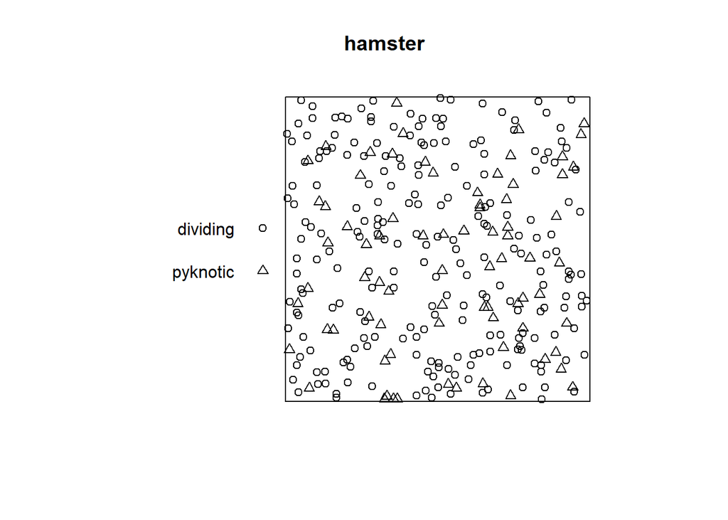

```r
plot(hamster)
```

## Dataset Chorley-Ribble

Data `chorley` memberikan alamat dari 58 kasus kanker laring dan 978 kasus kanker paru-paru, yang tercatat di Chorley and South Ribble Health Authority of Lancashire, Inggris, antara tahun 1974 dan 1983.

Ilustrasi berikut menunjukkan lokasi alamat kasus, serta lokasi insinerator industri yang sudah tidak digunakan lagi.

```r
chorley
```

```
Marked planar point pattern: 1036 points
Multitype, with levels = larynx, lung
window: polygonal boundary
enclosing rectangle: [343.45, 366.45] x [410.41, 431.79] km
```

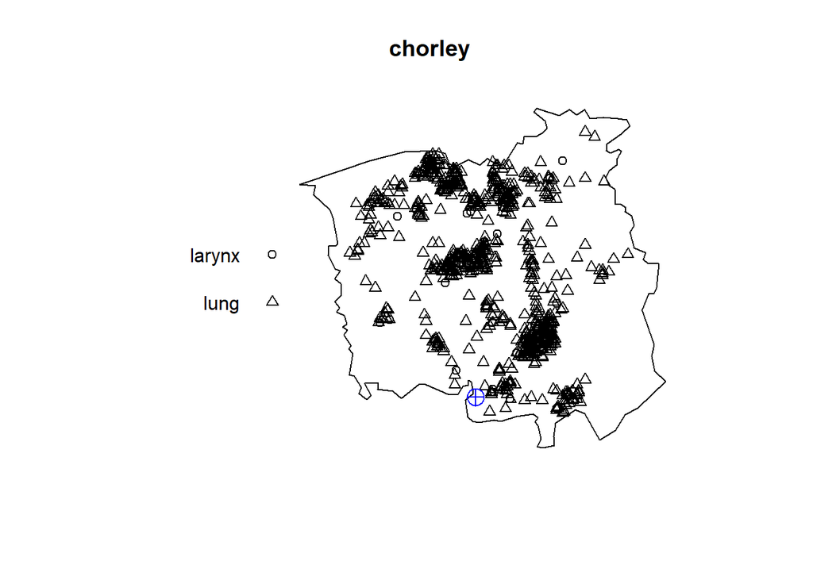

```r
plot(chorley)
points(chorley.extra$incin, pch = 10, cex = 2, col = "blue")
```

# Membuat Pola Titik Spasial

Dalam `spatstat`, pola titik spasial direpresentasikan sebagai objek kelas `ppp` (pola titik planar). Untuk membuat objek `ppp`, kita menggunakan fungsi `ppp()` yang meneruskan vektor `x` dan `y` dengan koordinat kejadian, dan jendela observasi yang berkelas `owin`.

Misalnya, di sini kita membuat pola titik spasial dari 100 titik yang dihasilkan secara acak di wilayah [0,1]×[0,2]. Pertama, kita gunakan fungsi `owin()` untuk membuat sebuah objek kelas `owin` dengan jendela observasi [0,1]×[0,2].

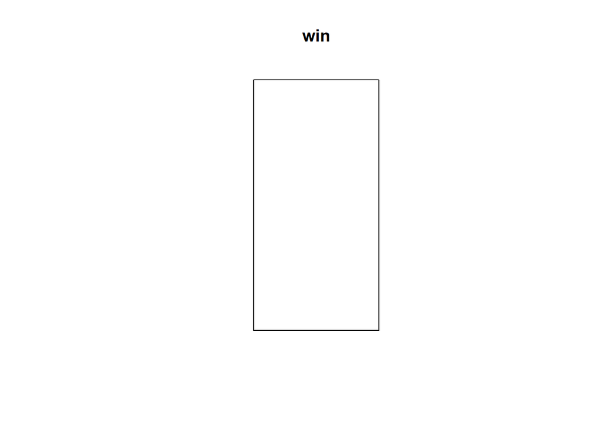

```r
win <- owin(xrange = c(0, 1), yrange = c(0, 2))
plot(win)
```

Kemudian, kita simulasikan 100 titik acak pada jendela observasi yang sudah dibuat.

```r
x <- runif(100, 0, 1)
y <- runif(100, 0, 2)
```

Terakhir, kita membuat objek ppp dengan fungsi ppp() yang menunjukkan x dan y sebagai koordinat kejadian, dan objek owin sebagai jendela.

```r
X <- ppp(x = x, y = y, window = win)
X
```

```
Planar point pattern: 100 points
window: rectangle = [0, 1] x [0, 2] units
```

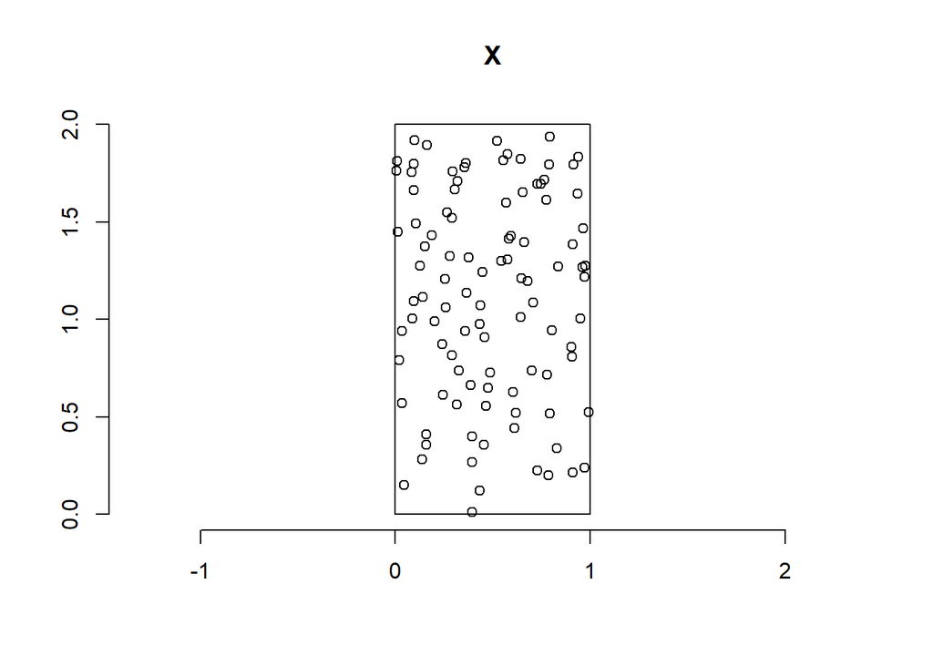

```r
plot(X)
axis(1)
axis(2)
```

Cara alternatif untuk mensimulasikan pola titik spasial dari titik acak seragam yang independen di suatu wilayah tertentu adalah dengan menggunakan fungsi `runifpoint()`. Argumen dari `runifpoint()` mencakup jumlah `n` titik dan jendelas kelas `owin` tempat pola titik disimulasikan.

```r
X <- runifpoint(n = 100, win = win)
```

Tanda yang menunjukkan informasi terkait peristiwa dapat ditetapkan dengan `marks()` atau `%mark%.`

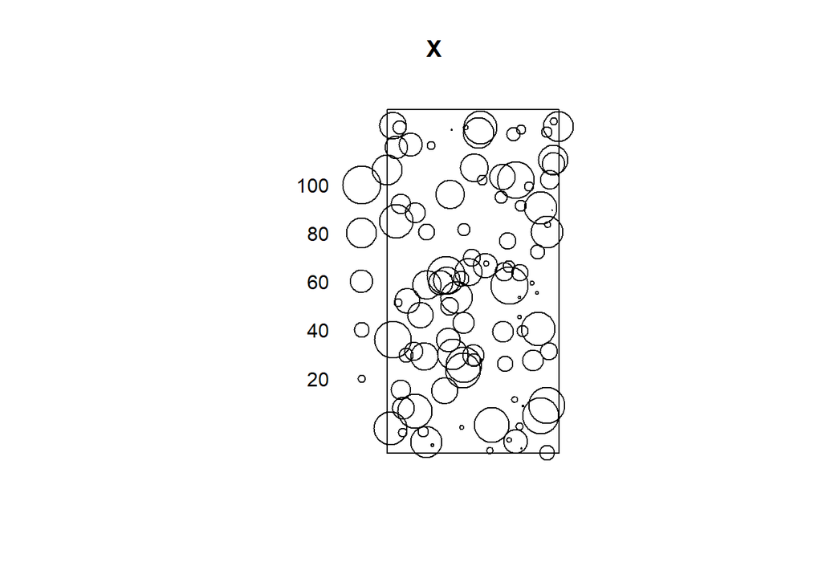

```r
# set marks with marks()
marks(X) <- 1:npoints(X)
# alternatively, set marks with %mark%
X <- X %mark% 1:npoints(X)
plot(X)
```

Perlu diperhatikan bahwa definisi jendela observasi yang mewakili wilayah studi pola titik perlu ditentukan secara hati-hati, karena hal ini memengaruhi visualisasi dan analisis data, dan mungkin juga kesimpulan yang diperoleh.

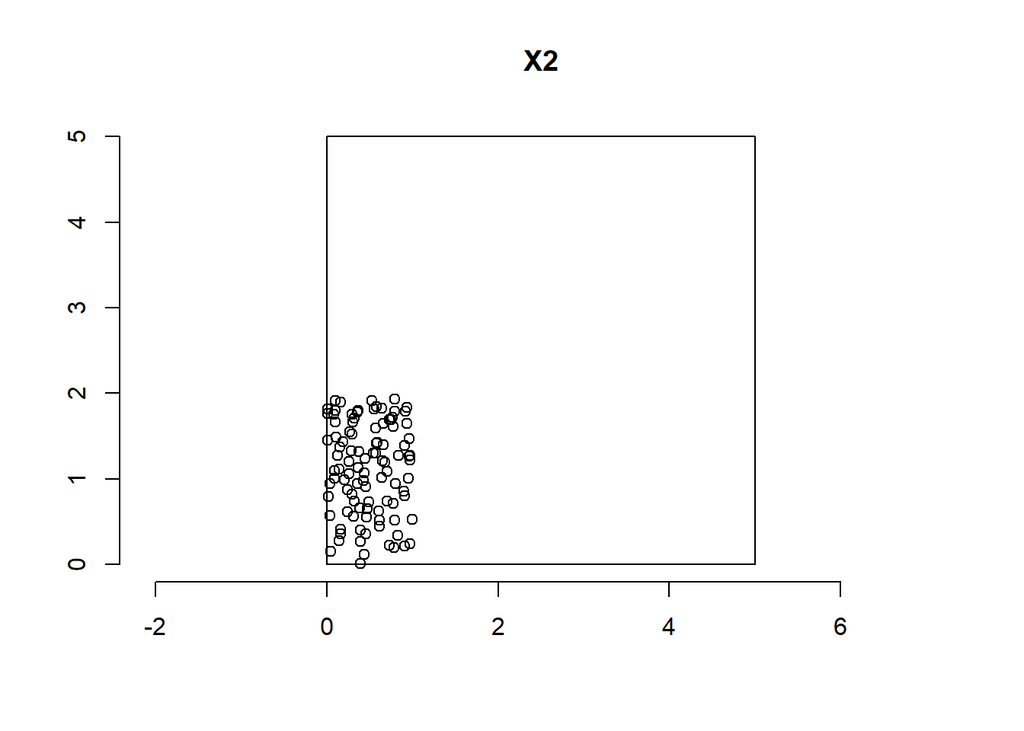

```r
win2 <- owin(xrange = c(0, 5), yrange = c(0, 5))
X2 <- ppp(x = x, y = y, window = win2)
plot(X2)
axis(1)
axis(2)
```

# Mengonversi antara objek ppp dan sf

## Dari ppp ke sf

Pertama, kita membuat bingkai data yang berisi koordinat dan tanda objek `ppp`. Kemudian, kita membuat objek `sf`dengan menggunakan fungsi `st_as_sf()` yang meneruskan bingkai data dan menentukan nama kolom yang berisi koordinat kejadian dalam argumen `coords`. Jendela pola titik juga dapat diubah menjadi `sf` dengan `st_as_sf(Window(X))`.

```r
library(sf)
```

```r
# ppp object
X <- longleaf
# create data frame with coordinates and marks
ddf <- data.frame(x = X$x, y = X$y, m = marks(X))
# create sf object with data frame and name of coordinates
d <- st_as_sf(ddf, coords = c("x", "y"))
```

```r
class(X)
```

```
[1] "ppp"
```

```r
class(d)
```

```
[1] "sf"         "data.frame"
```

## Dari sf ke ppp

Kita juga dapat mengonversi objek `sf` menjadi objek `ppp` dengan `as.ppp()` yang memberikan koordinat titik dan jendela observasi. Misalnya, di sini kita memperoleh koordinat objek `sf` dalam bentuk matriks dengan `st_coordinates()`, dan menganggap jendela observasi sebagai kotak pembatas data yang dapat diperoleh dengan `st_bbox()`.

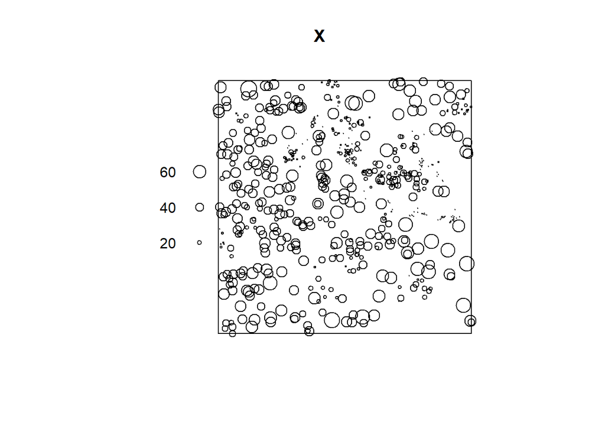

```r
X <- as.ppp(st_coordinates(d), st_bbox(d))
marks(X) <- d$m # alternatively we can use X <- X %mark% d$m
plot(X)
```

# Identifikasi Pola Titik

## 1: Metode Kuadran

Langkah-langkah metode kuadran adalah sebagai berikut:

1. Bagilah Daerah Studi menjadi beberapa sel yang berukuran sama. Ukuran Sel ditentukan oleh skala yang diinginkan
2. Tentukan Rata-rata Banyaknya Titik per sel
3. Tentukan Variance banyaknya titik per sel
4. Hitung perbandingan Ragam dengan Rata-rata (VMR)

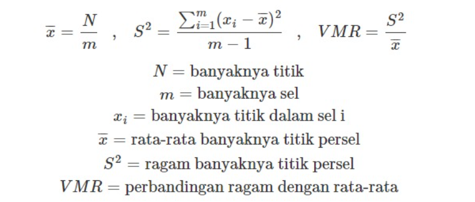

**Keterangan**

- **VMR = 0** titik menyebar **uniform** (sistematik)
- **VMR = 1** titik menyebar **acak**
- **VMR > 1** titik menyebar lebih **mengelompok** (kluster)

**Hipotesis**

H0: Titik menyebar acak

Jika m<30 didekati dengan sebaran *Khi Kuadrat*

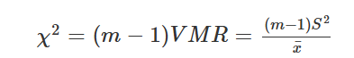

Jika m≥30 maka didekati dengan sebaran *Z*

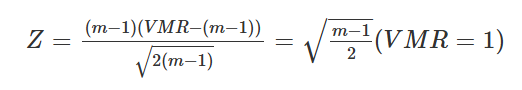

**Keputusan**

Jika α = 5%, Z>1.96 menolak H0 dan menerima H1 dengan kesimpulan **Kluster**

Jika α = 5%, Z>−1.96 menolak H0 dan menerima H1 dengan kesimpulan **Uniform**

#### Penerapan pada R

Contoh pola titik spasial menggunakan data `swedishpines` dari paket `spatstat`. Pola ini menggambarkan lokasi 71 pohon di sebidang hutan Swedia seluas 9,6 × 10 meter. Koordinat pola titik dinyatakan dalam desimeter (0,1 meter).

```r
library(spatstat)
data(swedishpines)
```

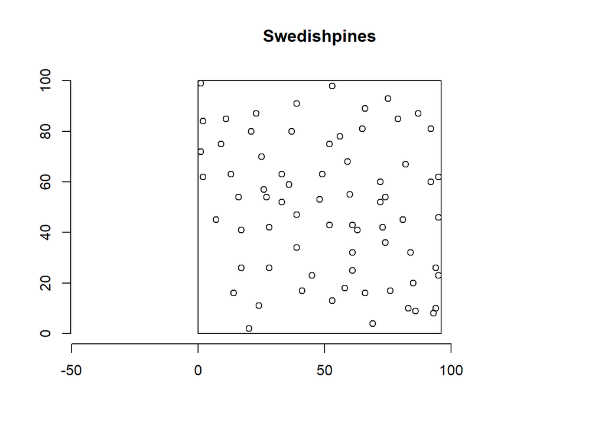

```r
A <- swedishpines
plot(A, main = "Swedishpines")
axis(1)
axis(2)
```

```r
summary(A)
```

```
Planar point pattern:  71 points
Average intensity 0.007395833 points per square unit (one unit = 0.1 metres)

Coordinates are integers
i.e. rounded to the nearest unit (one unit = 0.1 metres)

Window: rectangle = [0, 96] x [0, 100] units
Window area = 9600 square units
Unit of length: 0.1 metres
```

```r
den <- density(x = A, sigma = 10)
summary(den)
```

```
real-valued pixel image
128 x 128 pixel array (ny, nx)
enclosing rectangle: [0, 96] x [0, 100] units (one unit = 0.1 metres)
dimensions of each pixel: 0.75 x 0.78125 units
(one unit = 0.1 metres)
Image is defined on the full rectangular grid
Frame area = 9600 square units
Pixel values
    range = [0.001841662, 0.0156937]
    integral = 71.01604
    mean = 0.007397504
```

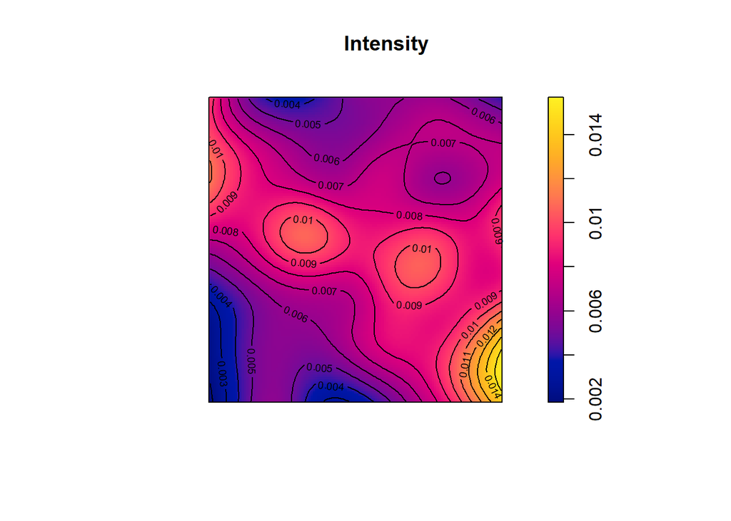

```r
plot(den, main = "Intensity")
contour(den, add = TRUE) # contour plot
```

Fungsi `quadratcount()` membagi jendela yang berisi pola titik menjadi `nx` × `ny` grid petak persegi panjang atau kuadrat dengan ukuran yang sama, dan menghitung jumlah titik di setiap kuadrat.

```r
q <- quadratcount(A, nx = 4, ny = 3)
q
```

```
             x
y             [0,24) [24,48) [48,72) [72,96]
  [66.7,100]       7       3       6       5
  [33.3,66.7)      5       9       7       7
  [0,33.3)         4       3       6       9
```

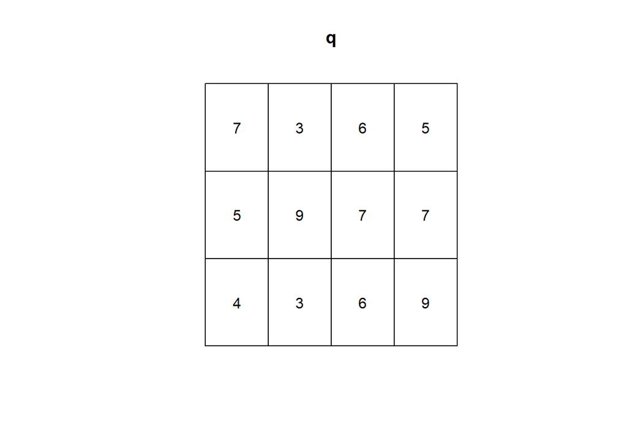

```r
plot(q)
```

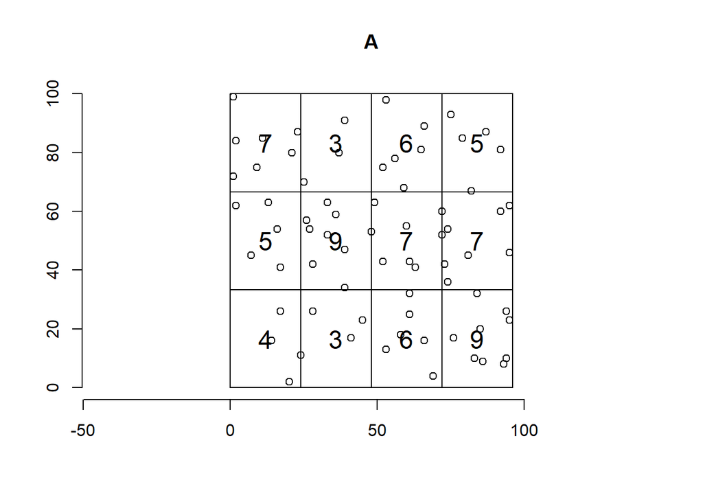

```r
plot(A)
axis(1)
axis(2)
plot(q, add = TRUE, cex = 1.5)
```

```r
mu <- mean(q)
sigma <- sd(q)^2
VMR <- sigma/mu
VMR
```

```
[1] 0.6901408
```

Fungsi ini `quadrat.test()` melakukan pengujian untuk pola titik tertentu. Argumen pertama dapat berupa pola titik kelas `ppp` atau hasil penerapan `quadratcount()` pada pola titik. Hipotesis alternatif ditentukan dalam argumen `alternative`.

- `alternative = "two.sided"` menguji

  H0: Titik menyebar acak vs

  H1: Titik tidak menyebar acak (uniform atau kluster)
- `alternative = "regular"` menguji

  H0: Titik menyebar acak atau kluster vs

  H1: Titik menyebar uniform
- `alternative = "clustered"` menguji

  H0: Titik menyebar acak atau uniform vs

  H1: Titik menyebar kluster

Secara default, `quadrat.test()` menilai signifikansi dengan membandingkan statistik uji yang diamati dengan distribusi chi-kuadrat (`method = "Chisq"`) tetapi juga dapat melakukan uji berbasis Monte Carlo dengan `method = "MonteCarlo"`.

```r
quadrat.test(q)
```

```
    Chi-squared test of CSR using quadrat counts

data:
X2 = 7.5915, df = 11, p-value = 0.5013
alternative hypothesis: two.sided

Quadrats: 4 by 3 grid of tiles
```

p-value yang diperoleh lebih besar dari tingkat signifikansi 0,05. Jadi kita gagal menolak hipotesis nol artinya terdapat bukti yang cukup untuk mengatakan bahwa titik menyebar secara acak.

```r
quadrat.test(q, alt = "regular")
```

```
    Chi-squared test of CSR using quadrat counts

data:
X2 = 7.5915, df = 11, p-value = 0.2506
alternative hypothesis: regular

Quadrats: 4 by 3 grid of tiles
```

```r
quadrat.test(q, alt = "clustered")
```

```
    Chi-squared test of CSR using quadrat counts

data:
X2 = 7.5915, df = 11, p-value = 0.7494
alternative hypothesis: clustered

Quadrats: 4 by 3 grid of tiles
```

## 2: Emipirical K-Function

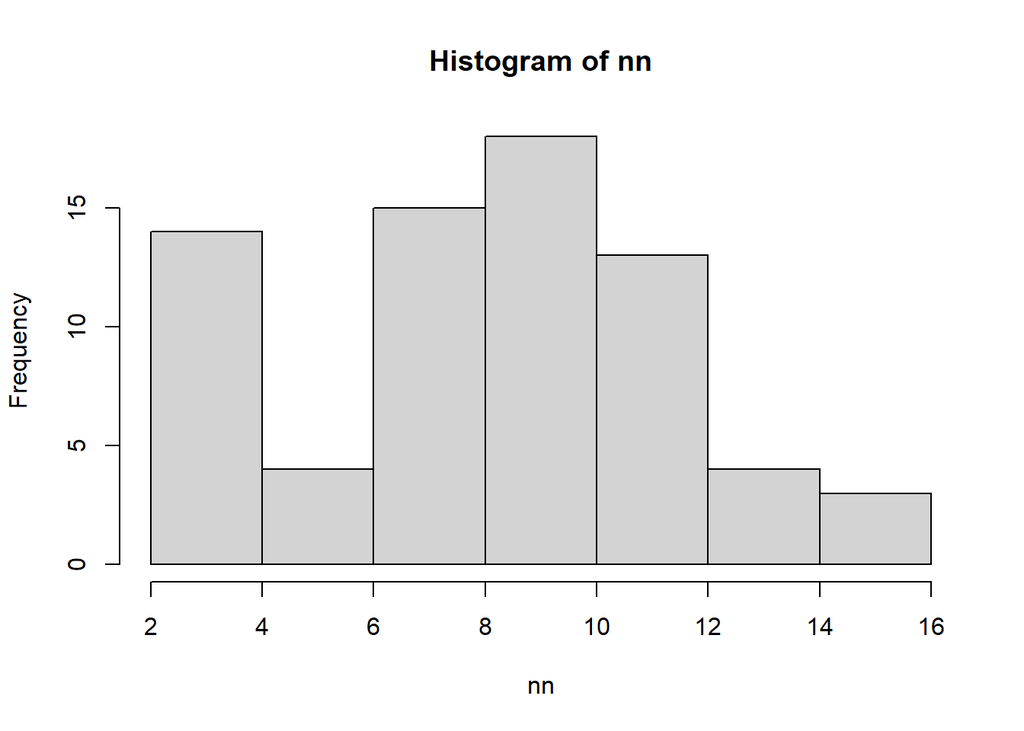

```r
nn <- nndist(swedishpines)
hist(nn)
```

#### **Fungsi K Empiris**

Fungsi K adalat alat eksplorasi yang dapat digunakan untuk menilai ketergantungan antara lokasi pada beberapa jarak.

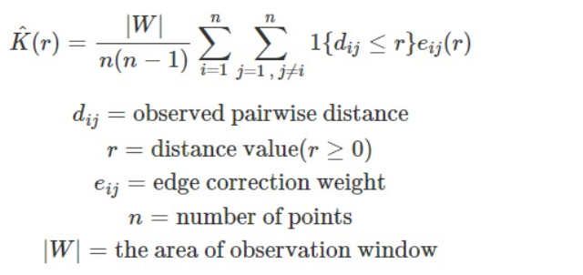

##### **Pola yang mungkin untuk** K^(r)

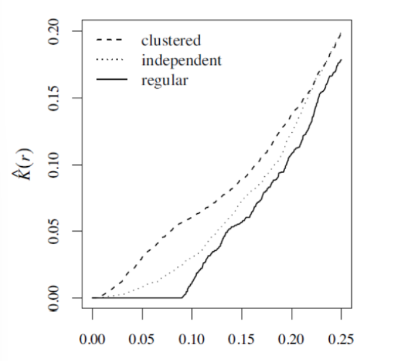

- **Garis putus-putus (clustered)** → contoh pola titik yang mengelompok. Nilainya di atas acuan.

  **Garis solid (regular)** → contoh pola titik yang teratur (titik-titik saling menghindar). Nilainya di bawah acuan.

  **Garis titik-titik (independent)** → **ini yang jadi acuan** → mewakili **CSR (Complete Spatial Randomness)** atau pola titik acak Poisson.

##### **Fungsi K Teoritis**

Untuk menentukan apakah nilai fungsi K relatif besar atau kecil, kita dapat membandingkan fungsi K untuk pola titik spasial yang diamati dengan fungsi K untuk proses Poisson homogen.

Kpois(r)=πr2

##### **Penggunaan Fungsi K Empiris**

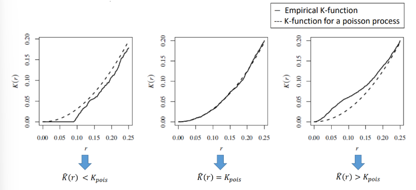

#### **Penerapan di R**

**Graphical Test**

Fungsi `Kest()` untuk memperkirakan fungsi K dari pola titik spasial yang disimulasikan dari proses Poisson homogen.

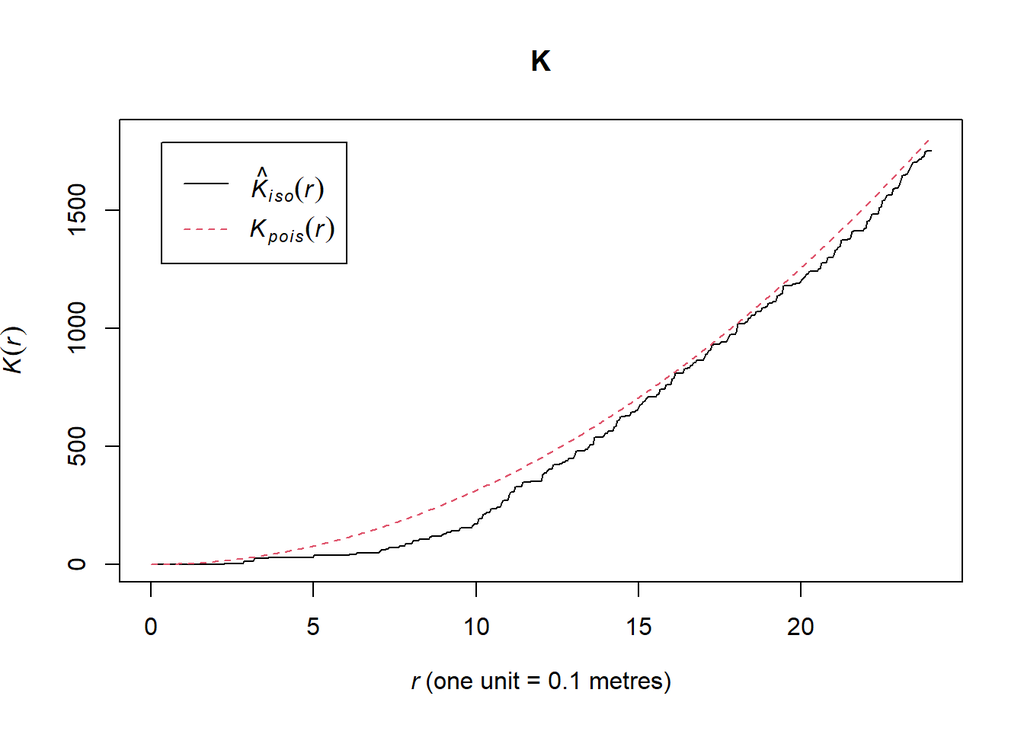

```r
K<- Kest(swedishpines, correction="Ripley")
plot(K)
```

```r
E<-envelope(swedishpines,Kest, nsim=99)
```

[output not shown]

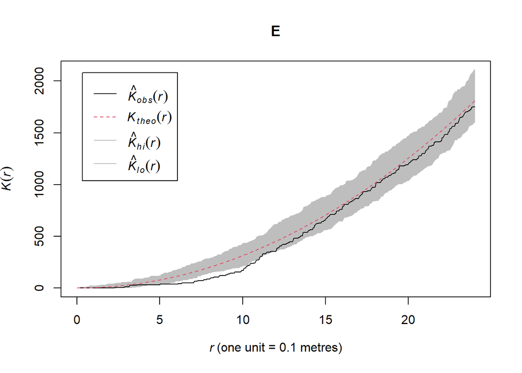

```r
plot(E)
```

**Non-graphical test (Maximum Absolute Deviation Test)**

```r
mad.test(swedishpines, Kest, nsim=99, alternative="two.sided")
```

[output not shown]

```
    Maximum absolute deviation test of CSR
    Monte Carlo test based on 99 simulations
    Summary function: K(r)
    Reference function: theoretical
    Alternative: two.sided
    Interval of distance values: [0, 24] units (one unit = 0.1 metres)
    Test statistic: Maximum absolute deviation
    Deviation = observed minus theoretical

data:  swedishpines
mad = 150.69, rank = 23, p-value = 0.23
```

- `alternative = "two.sided"` menguji

  H0: Titik menyebar acak vs

  H1: Titik tidak menyebar acak (uniform atau kluster)
- `alternative = "less"` menguji

  H0: Titik menyebar acak atau kluster vs

  H1: Titik menyebar uniform
- `alternative = "greater"` menguji

  H0: Titik menyebar acak atau uniform vs

  H1: Titik menyebar kluster